# Vectors

## Vector intro for linear algebra

- Vector: magnitude + direction
  - e.g. 5 mph (speed, which is a scalar) + east == velocity

Note:

- Speed is a scalar
- Velocity is a vector
- Vectors are independent of location. A vector starting at (0, 0) is equivalent to a vector starting at (1, 1) as long as they have the same magnitute + direction.

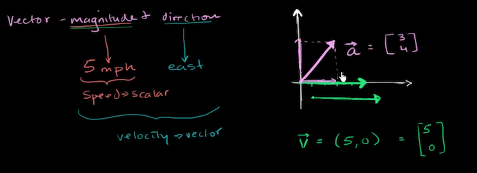

## Real coordinate spaces

Notation: $$\vec{v} = \begin{bmatrix} 5 \\ 0 \end{bmatrix} \in \mathbb{R}^2$$

where $\mathbb{R}^2$ is the 2-dimensional real coordinate space.

The 2-dimensional real coordinate space is all the possible real-valued 2-tuples.

A tuple is an ordered list of numbers.

### Exampe of 3-tuples

$\mathbb{R}^3$: 3-dimensional real coordinate space, described by real-valued 3-tuples

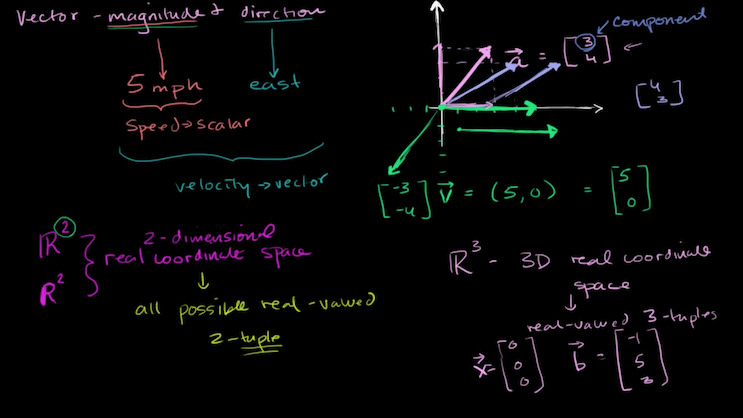

## Adding vectors algebraically & graphically

$$\vec{a} = \begin{bmatrix} 6 \\ -2 \end{bmatrix}, \; \vec{b} = \begin{bmatrix} -4 \\ 4 \end{bmatrix}, \; \vec{a}, \vec{b} \in \mathbb{R}^2$$$$\vec{a} + \vec{b} = \vec{b} + \vec{a} = \begin{bmatrix} 2 \\ 2 \end{bmatrix}$$

**Note:** Vectors don't only apply to displacement. They can apply to velocity and acceleration, and a whole series of things.

```python
import numpy as np
import matplotlib.pyplot as plt

V = np.array([[6, -2], [-4, 4], [2, 2]])
origin = np.array([[0, 6, 0],[0, -2, 0]]) # origin point

plt.quiver(*origin, V[:,0], V[:,1], color=['r','b','g'], angles='xy', scale_units='xy', scale=1)
plt.xlim(-1, 7)
plt.ylim(-3, 3)
```

[output not shown]

```
(-3, 3)
```

## Multiplying a vector by a scalar

$$\vec{a} = \begin{bmatrix} 2 \\ 1 \end{bmatrix} $$$$3\vec{a} = 3\begin{bmatrix} 2 \\ 1 \end{bmatrix} = \begin{bmatrix} 3 * 2 \\ 3 * 1 \end{bmatrix} = \begin{bmatrix} 6 \\ 3 \end{bmatrix} $$

```
(-1, 5)
```

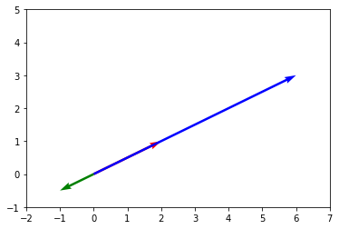

```python
import numpy as np
import matplotlib.pyplot as plt

V = np.array([[2, 1], [6, 3], [-1, -0.5]])
origin = np.array([[0, 0, 0],[0, 0, 0]]) # origin point

plt.quiver(*origin, V[:,0], V[:,1], color=['r','b','g'], angles='xy', scale_units='xy', scale=1)
plt.xlim(-2, 7)
plt.ylim(-1, 5)
```

## Unit vectors intro

Denote a unit vector: Use a hat instead of an arrow: $\hat{i}$

Given the unit vectors: $$ \hat{i} = \begin{bmatrix} 1 \\ 0 \end{bmatrix}, \; \hat{j} = \begin{bmatrix} 0 \\ 1 \end{bmatrix}$$

we can represent any 2 dimensional vector as a sum of scaled up versions of $\hat{i}$ and $\hat{j}$.

For example: $$ \vec{v} = \begin{bmatrix} 2 \\ 3 \end{bmatrix} = 2 \cdot \hat{i} + 3 \cdot \hat{j}$$

Once you get to three dimensions, you introduce $\hat{k} = \begin{bmatrix} 0 \\ 0 \\ 1 \end{bmatrix}$.

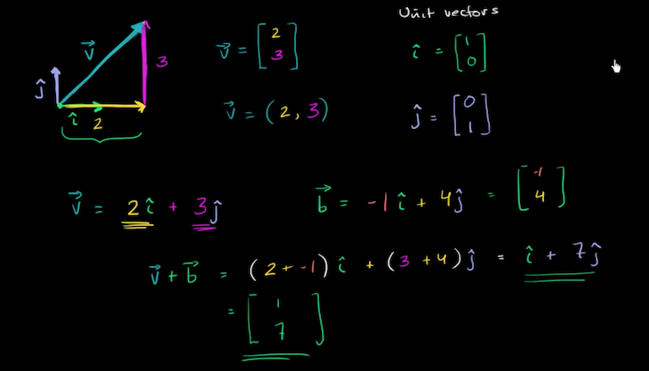

#### Quiz

1. What is the unit vector in the direction of $\vec{v} = \left( -1, -7 \right)$? $$\hat{v} = \frac{1}{\|\vec{v}\|} \cdot \vec{v} = \frac{1}{\sqrt{(-1)^2 + (-7)^2}} \cdot \vec{v} = \left( -\frac{1}{\sqrt{50}}, -\frac{7}{\sqrt{50}} \right) $$

## Parametric representation of lines

Set of colinear vectors: $$S = \{c \cdot \vec{v} \,|\, c \in \mathbb{R}\}$$ given $$\vec{v} = \begin{bmatrix} 2 \\ 1 \end{bmatrix}$$

If we view these vectors as position vectors (meaning a vector represents a point in space $\mathbb{R}^2$, the set is going to be represented as a line. You can think of $\vec{v}$ as a "slope vector".

Next, given $\vec{x} = [2, 4]^T$, we define a new set of vectors $L = \{\vec{x} + t\cdot \vec{v} \,|\, t \in \mathbb{R} \}$, which is also represented as a line in 2D.

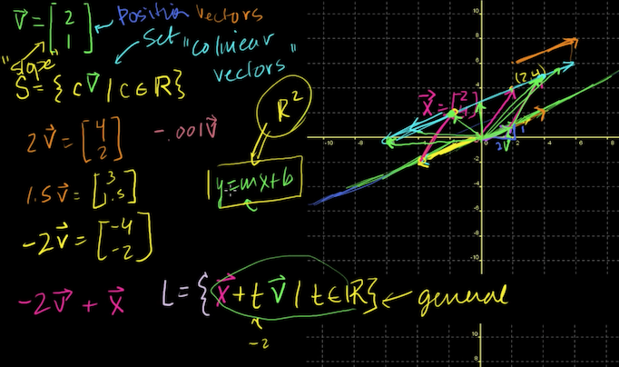

### Why bother thinking like this about lines?

This is a limited line equation that works well in $\mathbb{R}^2$: $$y = mx + b$$

Whereas the new definition using a set is much more general: $$L = \{\vec{x} + t\cdot \vec{v} \,|\, t \in \mathbb{R} \}$$ where $\vec{x}$ and $\vec{v}$ both $\in \mathbb{R}^2$, meaning they're 2-dimensional vectors, but we can extend it to an arbitrary number of dimensions.

In the classic algebra problem where you need to find the equation for the line (here: the set definition for the line).

### Find the parameterization of a line in 2D

Given two vectors / points $\vec{a} = [2, 1]^T$ and $\vec{b} = [0, 3]^T$, find the parameterization of the line that goes through these two points.

Two possible solutions: $$ L = \{\vec{b} + t(\vec{b} - \vec{a}) | t \in \mathbb{R} \}$$ $$ L = \{\vec{a} + t(\vec{b} - \vec{a}) | t \in \mathbb{R} \}$$

Using the vectors given above, we get: $$ L = \{\begin{bmatrix} 0 \\ 3 \end{bmatrix} + t\begin{bmatrix} -2 \\ 2 \end{bmatrix} | t \in \mathbb{R} \}$$

Written as parametric equations: $$ \vec{L} = \begin{bmatrix} l_1 \\ l_2 \end{bmatrix} = \begin{bmatrix} -2t \\ 2t + 3 \end{bmatrix}$$

The traditional parametric definition of the line is: $$x = -2t$$ $$y = 2t + 3$$

### Find the parameterization of a line in 3D

In $\mathbb{R}^3$ the only way to define a line is to have a parametric equation.

Given two three-dimensional points $P_1$ and $P_2$, the line going through them can be defined as $$ L = \{\vec{P}_1 + t \cdot (\vec{P}_1 - \vec{P}_2) \;|\; t \in \mathbb{R} \}$$

E.g. $x + y + z = k$ is a plane, not a line.

## Add vectors: magnitude & direction to component

[Review topic on Khan Academy](https://www.khanacademy.org/math/precalculus/x9e81a4f98389efdf:vectors/x9e81a4f98389efdf:component-form/a/vector-magnitude-and-direction-review)

### Problem 1

Given:

- $\vec{v}$ with magnitude $8$ and direction angle $140°$
- $\vec{w}$ with magnitude $4$ and direction angle $40°$

Find:

- $\vec{v} + \vec{w}$

$$\vec{v} + \vec{w} = \begin{pmatrix} 8 \cdot cos(140°) + 4 \cdot cos(40°) \\ 8 \cdot sin(140°) + 4 \cdot sin(40°) \end{pmatrix} = \begin{pmatrix} -3.064 \\ 7.7134 \end{pmatrix} $$

```python
import numpy as np
import math

r = np.array([8, 4])
theta = np.array([math.radians(140), math.radians(40)])
result = [sum(r * np.cos(theta)), sum(r * np.sin(theta))]
print("v + w = ", result)
```

```
v + w =  [-3.0641777724759107, 7.713451316238473]
```

### Problem 2

Given: Vectors in form $(r, \theta)$ where $r$ is the magnitude and $\theta$ is the direction angle

- $\vec{v} = (7, 160°)$
- $\vec{w} = (9, 20°)$

Find:

- $\vec{v} + \vec{w}$

```python
r = np.array([7, 9])
theta = np.array([math.radians(160), math.radians(20)])
result = [sum(r * np.cos(theta)), sum(r * np.sin(theta))]
print("v + w = ", result)
```

```
v + w =  [1.8793852415718177, 5.4723222932107]
```

```python
from IPython.display import HTML
import warnings; warnings.simplefilter('ignore')
HTML('<iframe width="560" height="315" src="https://www.youtube.com/embed/A05n32Bl0aY" frameborder="0" allow="accelerometer; autoplay; clipboard-write; encrypted-media; gyroscope; picture-in-picture" allowfullscreen></iframe>')
```

[video not shown]